# R crash course

## Install R (Windows)

This is a quick introduction to the R programming language and the RStudio development environment, to be able to do some exploratory data analysis on the results of the PacMAN bioinformatics pipeline.

Install the latest R from https://ftp.belnet.be/mirror/CRAN/bin/windows/base/.

## Install Rstudio (Windows)

Install Rstudio Desktop from https://posit.co/downloads/.

Open RStudio and create a new R script:

[figure not shown]

Selections or individual lines of R code in the editor panel can be executed using the `Run` button at the top of the editor, or by pressing `Ctrl`+`Enter`. Results will be visible in the Console panel below. You can also type commands directly into the Console. On the top right we have the Environment panel and below that the Files panel.

In the Files panel, create a new working directory using the `New Folder` button. Go into the directory and select `More` > `Set As Working Directory`.

## R basics

### Assignment

Assign values to objects with the `<-` operator. To type this operator in one go, use `Alt`+`-`.

```r
weight <- 32
color <- "yellow"
edible <- TRUE
```

### Comments

Add comments in your code by typing a `#`. Anything to the right of this will be ignored by the interpreter.

```r
# changing the weight
weight <- 45 # used to be 32
```

### Types

The objects we just created have different types:

```r
typeof(weight)
```

```
## [1] "double"
```

```r
typeof(color)
```

```
## [1] "character"
```

```r
typeof(edible)
```

```
## [1] "logical"
```

### Math

Now let’s try some math:

```r
n <- 5
total_weight <- weight * n
total_weight
```

```
## [1] 225
```

### Functions

A function can be defined like this:

```r
surface_area <- function(width, height) {
  return(width * height)
}

surface_area(3, 2)
```

```
## [1] 6
```

If you use argument names, their order can be changed:

```r
surface_area(height = 2, width = 3)
```

```
## [1] 6
```

Function arguments can have default value:

```r
surface_area <- function(width, height = 8) {
  return(width * height)
}

surface_area(3)
```

```
## [1] 24
```

### Accessing documentation

To get more information about a function, use `?`.

```r
?class
```

### Vectors

Vectors are sequences of elements which have the same type. Values can be combined into a vector using the `c()` function.

```r
numbers <- c(1, 2, 3)
numbers
```

```
## [1] 1 2 3
```

```r
length(numbers)
```

```
## [1] 3
```

Sequences of numbers can be generated using `:`:

```r
x <- 1:10
x
```

```
##  [1]  1  2  3  4  5  6  7  8  9 10
```

We can also do math with vectors:

```r
x ^ 2
```

```
##  [1]   1   4   9  16  25  36  49  64  81 100
```

Sequences with smaller increments can be created using `seq()`:

```r
x <- seq(0, 2 * pi, by = 0.1)
y <- sin(x)

x
```

```
##  [1] 0.0 0.1 0.2 0.3 0.4 0.5 0.6 0.7 0.8 0.9 1.0 1.1 1.2 1.3 1.4 1.5 1.6 1.7 1.8
## [20] 1.9 2.0 2.1 2.2 2.3 2.4 2.5 2.6 2.7 2.8 2.9 3.0 3.1 3.2 3.3 3.4 3.5 3.6 3.7
## [39] 3.8 3.9 4.0 4.1 4.2 4.3 4.4 4.5 4.6 4.7 4.8 4.9 5.0 5.1 5.2 5.3 5.4 5.5 5.6
## [58] 5.7 5.8 5.9 6.0 6.1 6.2
```

```r
y
```

```
##  [1]  0.00000000  0.09983342  0.19866933  0.29552021  0.38941834  0.47942554
##  [7]  0.56464247  0.64421769  0.71735609  0.78332691  0.84147098  0.89120736
## [13]  0.93203909  0.96355819  0.98544973  0.99749499  0.99957360  0.99166481
## [19]  0.97384763  0.94630009  0.90929743  0.86320937  0.80849640  0.74570521
## [25]  0.67546318  0.59847214  0.51550137  0.42737988  0.33498815  0.23924933
## [31]  0.14112001  0.04158066 -0.05837414 -0.15774569 -0.25554110 -0.35078323
## [37] -0.44252044 -0.52983614 -0.61185789 -0.68776616 -0.75680250 -0.81827711
## [43] -0.87157577 -0.91616594 -0.95160207 -0.97753012 -0.99369100 -0.99992326
## [49] -0.99616461 -0.98245261 -0.95892427 -0.92581468 -0.88345466 -0.83226744
## [55] -0.77276449 -0.70554033 -0.63126664 -0.55068554 -0.46460218 -0.37387666
## [61] -0.27941550 -0.18216250 -0.08308940
```

### Subsetting vectors

Vectors can be subsetted using indices in square brackets:

```r
x[1]
```

```
## [1] 0
```

```r
x[1:3]
```

```
## [1] 0.0 0.1 0.2
```

```r
x[c(5, 4, 3)]
```

```
## [1] 0.4 0.3 0.2
```

Another option is to use conditional subsetting:

```r
selection <- y > 0.95
selection
```

```
##  [1] FALSE FALSE FALSE FALSE FALSE FALSE FALSE FALSE FALSE FALSE FALSE FALSE
## [13] FALSE  TRUE  TRUE  TRUE  TRUE  TRUE  TRUE FALSE FALSE FALSE FALSE FALSE
## [25] FALSE FALSE FALSE FALSE FALSE FALSE FALSE FALSE FALSE FALSE FALSE FALSE
## [37] FALSE FALSE FALSE FALSE FALSE FALSE FALSE FALSE FALSE FALSE FALSE FALSE
## [49] FALSE FALSE FALSE FALSE FALSE FALSE FALSE FALSE FALSE FALSE FALSE FALSE
## [61] FALSE FALSE FALSE
```

```r
y[selection]
```

```
## [1] 0.9635582 0.9854497 0.9974950 0.9995736 0.9916648 0.9738476
```

### Data frames

Data frames are table like structures. They can be created from vectors:

```r
mountains <- data.frame(
  name = c("Mount Everest", "K2", "Kangchenjunga", "Lhotse"),
  height = c(8848, 8611, 8586, 8516),
  ascent = c(1953, 1954, 1955, 1956)
)

mountains
```

```
##            name height ascent
## 1 Mount Everest   8848   1953
## 2            K2   8611   1954
## 3 Kangchenjunga   8586   1955
## 4        Lhotse   8516   1956
```

Display the structure of a data frame with `str()`:

```r
str(mountains)
```

```
## 'data.frame':    4 obs. of  3 variables:
##  $ name  : chr  "Mount Everest" "K2" "Kangchenjunga" "Lhotse"
##  $ height: num  8848 8611 8586 8516
##  $ ascent: num  1953 1954 1955 1956
```

### Subsetting data frames

Subsetting data frames also works with indices in square brackets, but now in two dimensions (rows and columns):

```r
mountains[1, 1]
```

```
## [1] "Mount Everest"
```

```r
mountains[1,]
```

```
##            name height ascent
## 1 Mount Everest   8848   1953
```

```r
mountains[,1]
```

```
## [1] "Mount Everest" "K2"            "Kangchenjunga" "Lhotse"
```

Alternatively, use column names, either in square brackets or with the `$` operator:

```r
mountains[,"name"]
```

```
## [1] "Mount Everest" "K2"            "Kangchenjunga" "Lhotse"
```

```r
mountains[1, "name"]
```

```
## [1] "Mount Everest"
```

```r
mountains$name
```

```
## [1] "Mount Everest" "K2"            "Kangchenjunga" "Lhotse"
```

```r
mountains$name[1]
```

```
## [1] "Mount Everest"
```

### Factors

Categorical variables can be converted to factors:

```r
mountains$name
```

```
## [1] "Mount Everest" "K2"            "Kangchenjunga" "Lhotse"
```

```r
factor(mountains$name)
```

```
## [1] Mount Everest K2            Kangchenjunga Lhotse
## Levels: K2 Kangchenjunga Lhotse Mount Everest
```

```r
typeof(factor(mountains$name))
```

```
## [1] "integer"
```

### Missing data

Missing data in R is represented by `NA`:

```r
heights <- c(2, 5, NA, NA, 8)
```

Some functions have a `na.rm` argument to ignore missing values:

```r
mean(heights)
```

```
## [1] NA
```

```r
mean(heights, na.rm = TRUE)
```

```
## [1] 5
```

To remove missing values from a vector, use `na.omit()`:

```r
na.omit(heights)
```

```
## [1] 2 5 8
## attr(,"na.action")
## [1] 3 4
## attr(,"class")
## [1] "omit"
```

## Packages

Packages are reusable collections of code developed by the community. Packages can be installed from different sources, including The Comprehensive R Archive Network (CRAN) and GitHub. To install a package from CRAN, use `install.packages()`:

```r
install.packages("remotes")
```

Packages can be loaded using `library()`:

```r
library(remotes)
```

Alternatively, you can use the `::` operator to select a function from a particular package:

```r
remotes::available_packages()
```

Packages hosted on GitHub can be installed using the `remotes` package:

```r
remotes::install_github("iobis/robis")
```

## Graphics

### Base graphics

R has built-in graphics capabilities.

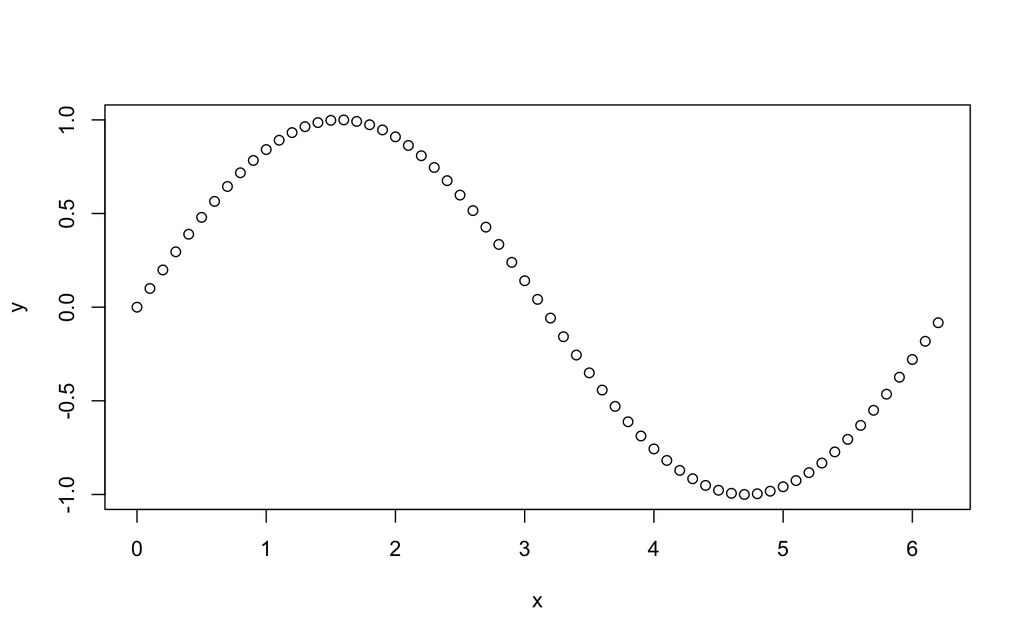

```r
plot(x, y)
```

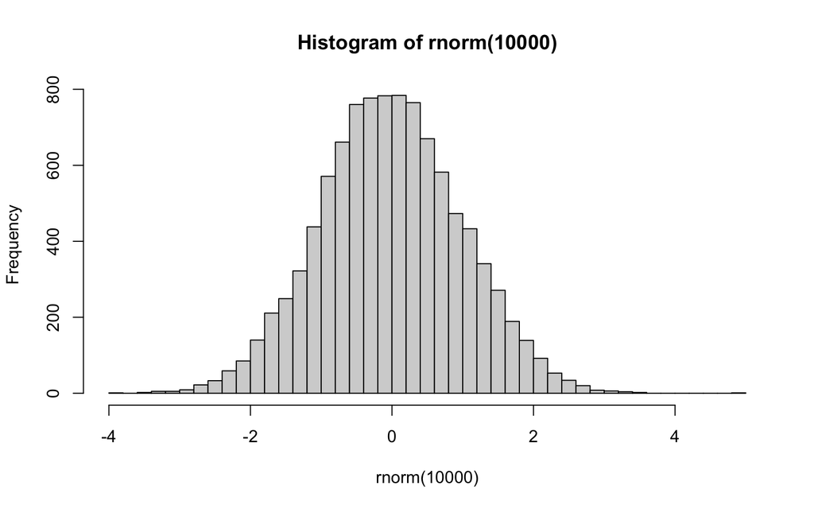

```r
hist(rnorm(10000), breaks = 50)
```

### ggplot2 graphics

ggplot2 is an alternative graphics framework, based on Hadley Wickham’s [Layered Grammar of Graphics](http://vita.had.co.nz/papers/layered-grammar.html) which builds on [The Grammar of Graphics](https://link.springer.com/book/10.1007/0-387-28695-0) by Leland Wilkinson.

In ggplot2, graphics layers are composed of the following elements: data, mapping between variables and aesthetics, geometric objects, statistical transformations, scales, the coordinate system, and facets.

In practice, this works like this:

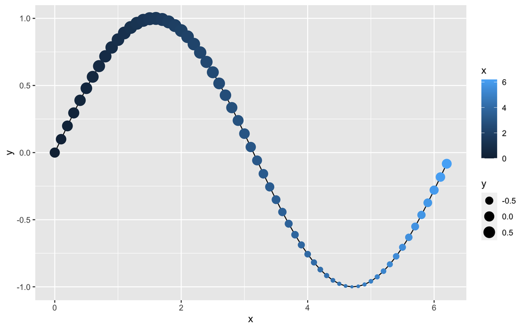

```r
library(ggplot2)

df <- data.frame(x, y)

ggplot(data = df) +
  geom_line(aes(x = x, y = y)) +
  geom_point(aes(x = x, y = y, color = x, size = y))
```

This is a rather basic graph, but [the possibilities are endless](https://exts.ggplot2.tidyverse.org/gallery/).

## Input and output

R has a number of built-in functions for reading files, such as `read.table()` and `read.csv()` for tabular data, and `readLines()` for reading text files. In addition, packages exist for reading these and other file types, such as `readr` for tabular data, `xlsx` for reading Excel spreadsheets, `arrow` for reading Parquet files, `sf` for reading geospatial datasets, `ncdf4` for reading NetCDF, and `seqinr` for reading fasta files. Analogous functions exist for writing files.

R also has two native file formats for reading and writing objects: RData files (multiple objects) and RDS files (single object).

```r
save(x, y, file = "xy.rda")
load("xy.rda")

saveRDS(x, file = "x.rds")
x <- readRDS("x.rds")
```

## The tidyverse

The [tidyverse](https://www.tidyverse.org/) is a collection of packages focusing on data science, with a common philosophy and grammar.

```r
tidyverse::tidyverse_packages()
```

```
##  [1] "broom"         "cli"           "crayon"        "dbplyr"
##  [5] "dplyr"         "dtplyr"        "forcats"       "ggplot2"
##  [9] "googledrive"   "googlesheets4" "haven"         "hms"
## [13] "httr"          "jsonlite"      "lubridate"     "magrittr"
## [17] "modelr"        "pillar"        "purrr"         "readr"
## [21] "readxl"        "reprex"        "rlang"         "rstudioapi"
## [25] "rvest"         "stringr"       "tibble"        "tidyr"
## [29] "xml2"          "tidyverse"
```

Some notable tidyverse packages are:

| Package | Description |
| --- | --- |
| dplyr | A Grammar of Data Manipulation |
| tidyr | Tidy Messy Data |
| stringr | Simple, Consistent Wrappers for Common String Operations |
| readr | Read Rectangular Text Data |
| ggplot2 | Create Elegant Data Visualisations Using the Grammar of Graphics |
| purrr | Functional Programming Tools |

The [tidyverse style guide](https://style.tidyverse.org/) recommends using the pipe operator `%>%` from the `magrittr` package to emphasize sequences of actions. The pipe operator passes the output of a function as the first argument of the next one. Since version 4.1.0, a pipe operator `|>` has been added to R (note that there are [a few differences](https://r4ds.hadley.nz/workflow-pipes.html#vs)).

By combining pipes and `dplyr` verbs, we can write very readble data manipulation sequences. For exalple:

```r
library(dplyr)

head(iris)
```

```
##   Sepal.Length Sepal.Width Petal.Length Petal.Width Species
## 1          5.1         3.5          1.4         0.2  setosa
## 2          4.9         3.0          1.4         0.2  setosa
## 3          4.7         3.2          1.3         0.2  setosa
## 4          4.6         3.1          1.5         0.2  setosa
## 5          5.0         3.6          1.4         0.2  setosa
## 6          5.4         3.9          1.7         0.4  setosa
```

```r
iris %>%
  group_by(Species) %>%
  summarize(
    sepal_mean = mean(Sepal.Length),
    sepal_min = min(Sepal.Length),
    sepal_max = max(Sepal.Length)
  )
```

```
## # A tibble: 3 × 4
##   Species    sepal_mean sepal_min sepal_max
##   <fct>           <dbl>     <dbl>     <dbl>
## 1 setosa           5.01       4.3       5.8
## 2 versicolor       5.94       4.9       7
## 3 virginica        6.59       4.9       7.9
```

## Style guides

Consistent code style makes code easier to read an collaborate on. If you are unsure about your R style, check the following style guides:

- http://adv-r.had.co.nz/Style.html
- https://google.github.io/styleguide/Rguide.html
- https://style.tidyverse.org/